# DBclustKM

## Agglomerative Clustering

Agglomerative clustering is a hierarchical clustering algorithm that builds clusters step by step, starting with individual data points and merging them based on proximity. One of the key advantages of agglomerative clustering is its ability to create a hierarchy, offering a visualization (dendrogram) that shows how clusters are formed at different levels of granularity. This is useful when the user is unsure about the optimal number of clusters since the algorithm doesn't require this parameter upfront.

However, agglomerative clustering can be computationally expensive, especially for large datasets, because it requires calculating distances between all data points at each iteration. Additionally, this method can be sensitive to noise and outliers, often merging them into existing clusters or failing to detect them as anomalies.

## KMeans

KMeans is a widely used clustering algorithm that excels in its simplicity and speed. It works by iteratively assigning points to the nearest centroid and then recalculating the centroids based on the cluster's mean. This process is repeated until convergence. One of KMeans' main strengths is its efficiency, which makes it well-suited for large datasets. It's also straightforward to implement and tends to perform well on datasets where the clusters are roughly spherical or blob-shaped.

However, KMeans has several limitations. It requires the number of clusters (k) to be specified beforehand, which can be a challenge if the structure of the data is not known in advance. Additionally, the algorithm is sensitive to the initial placement of centroids; poorly initialized centroids can lead to suboptimal clustering. KMeans also assumes that clusters are spherical and evenly sized, which means it struggles with complex shapes like moons, circles, or irregular patterns.

## DBScan

DBScan (Density-Based Spatial Clustering of Applications with Noise) is designed to find clusters based on density. This allows it to detect clusters of arbitrary shape, such as moon- or circle-shaped clusters, and handle datasets with noise or outliers effectively. Unlike KMeans, DBScan does not require the number of clusters to be specified in advance. Instead, it relies on two parameters: epsilon (ε), which defines the radius of the neighborhood, and minPts, the minimum number of points required to form a dense region. If points do not belong to any dense region, they are classified as noise.

Despite these strengths, DBScan has its own drawbacks. The algorithm's performance is highly sensitive to the choice of ε and minPts, which can be challenging to determine for datasets with varying densities. DBScan may also struggle when the dataset contains clusters of significantly different densities, as it could fail to distinguish between them or wrongly classify some as noise.

```python
import numpy as np
import pandas as pd
import matplotlib.pyplot as plt
import seaborn as sns
import random

import plotly
import plotly.express as px
import plotly.offline as pyo
import plotly.figure_factory as ff
import plotly.graph_objects as go
import plotly.io as pio

from plotly.offline import iplot, init_notebook_mode
init_notebook_mode(connected = True)

from sklearn.datasets import make_blobs
from sklearn.datasets import make_circles
from sklearn.datasets import make_moons

from sklearn.cluster import DBSCAN
from sklearn.cluster import KMeans
from sklearn.cluster import AgglomerativeClustering
from plotly.subplots import make_subplots

from IPython.display import IFrame

np.random.seed(41)
```

```python
blobs_data = make_blobs(n_samples=1000, cluster_std=0.7, random_state=24, center_box=(-4.0, 4.0))[0]
blobs = pd.DataFrame(blobs_data, columns=['x1', 'x2'])

circle_data = make_circles(n_samples=1000, factor=0.5, noise=0.05)[0]
circle = pd.DataFrame(circle_data, columns=['x1', 'x2'])

moons_data = make_moons(n_samples=1000, noise=0.05)[0]
moons = pd.DataFrame(moons_data, columns=['x1', 'x2'])

random_data = np.random.rand(1500, 2)
random = pd.DataFrame(random_data, columns=['x1', 'x2'])
```

**Blob-shaped data refers to clusters that are spherical or circular and well-separated. KMeans is ideal for this type of data, as it assumes clusters are circular and equally spaced, so it can easily detect and separate blob-like clusters. Agglomerative clustering also performs well on blob-shaped data since its distance-based merging method is compatible with this type of clustering pattern. DBScan can handle blob-shaped clusters too, but tuning the ε and minPts parameters properly is key for it to function well in this context.**

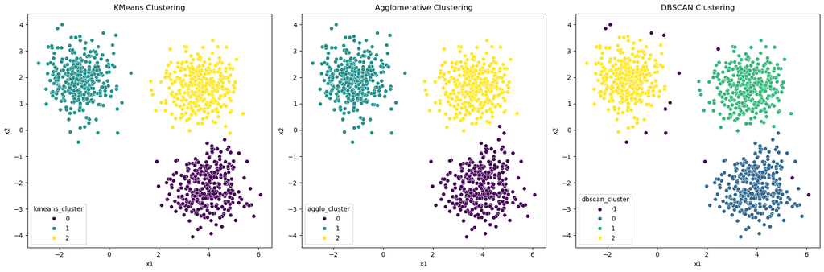

```python
# Create figure and axes for subplots
fig, axes = plt.subplots(1, 3, figsize=(18, 6))

# KMeans Clustering
kmeans = KMeans(n_clusters=3)
kmeans.fit(blobs_data)
blobs['kmeans_cluster'] = kmeans.labels_
sns.scatterplot(data=blobs, x='x1', y='x2', hue='kmeans_cluster', palette='viridis', ax=axes[0])
axes[0].set_title('KMeans Clustering')

# Agglomerative Clustering
agglo = AgglomerativeClustering(n_clusters=3, metric='euclidean')
blobs['agglo_cluster'] = agglo.fit_predict(blobs_data)
sns.scatterplot(data=blobs, x='x1', y='x2', hue='agglo_cluster', palette='viridis', ax=axes[1])
axes[1].set_title('Agglomerative Clustering')

# DBSCAN Clustering
dbscan = DBSCAN(eps=0.5, min_samples=5)
blobs['dbscan_cluster'] = dbscan.fit_predict(blobs_data)
sns.scatterplot(data=blobs, x='x1', y='x2', hue='dbscan_cluster', palette='viridis', ax=axes[2])
axes[2].set_title('DBSCAN Clustering')

# Adjust the layout
plt.tight_layout()
plt.show()
```

# [Interactive plot](https://test-app-y0lp.onrender.com/ml/charts-KMclustDB/)

**Moon-shaped data represents non-spherical clusters with curved patterns. KMeans performs poorly here because it assumes that clusters are spherical and evenly sized, which does not align with the shape of the data. It tends to force boundaries where they don't belong, splitting the curved shapes into arbitrary parts. Agglomerative clustering, on the other hand, can perform decently since it doesn't assume cluster shapes, but it may still have difficulty with closely linked data points. DBScan is the best-suited algorithm for this kind of data, as it can naturally detect the non-spherical, crescent-shaped structures based on density, without assuming a particular form.**

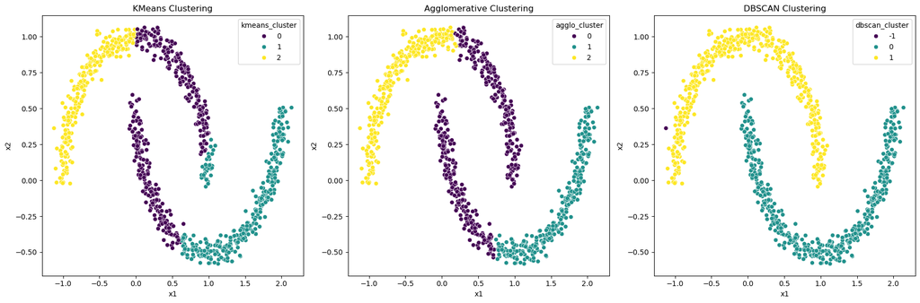

```python
# Create figure and axes for subplots
fig, axes = plt.subplots(1, 3, figsize=(18, 6))

# KMeans Clustering
kmeans = KMeans(n_clusters=3)
kmeans.fit(moons_data)
moons['kmeans_cluster'] = kmeans.labels_
sns.scatterplot(data=moons, x='x1', y='x2', hue='kmeans_cluster', palette='viridis', ax=axes[0])
axes[0].set_title('KMeans Clustering')

# Agglomerative Clustering
agglo = AgglomerativeClustering(n_clusters=3, metric='euclidean')
moons['agglo_cluster'] = agglo.fit_predict(moons_data)
sns.scatterplot(data=moons, x='x1', y='x2', hue='agglo_cluster', palette='viridis', ax=axes[1])
axes[1].set_title('Agglomerative Clustering')

# DBSCAN Clustering
dbscan = DBSCAN(eps=0.1, min_samples=5)
moons['dbscan_cluster'] = dbscan.fit_predict(moons_data)
sns.scatterplot(data=moons, x='x1', y='x2', hue='dbscan_cluster', palette='viridis', ax=axes[2])
axes[2].set_title('DBSCAN Clustering')

# Adjust the layout
plt.tight_layout()
plt.show()
```

# [Interactive plot](https://test-app-y0lp.onrender.com/ml/charts-KMclustDB2/)

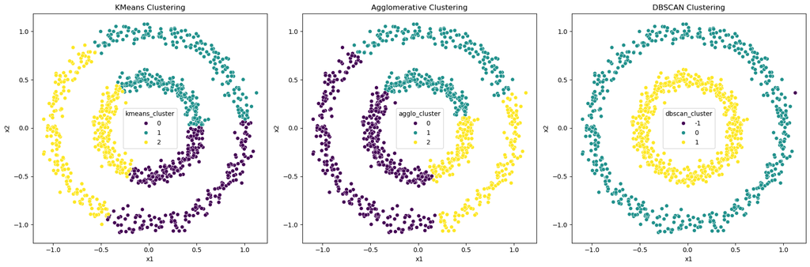

```python
# Create figure and axes for subplots
fig, axes = plt.subplots(1, 3, figsize=(18, 6))

# KMeans Clustering
kmeans = KMeans(n_clusters=3)
kmeans.fit(circle_data)
circle['kmeans_cluster'] = kmeans.labels_
sns.scatterplot(data=circle, x='x1', y='x2', hue='kmeans_cluster', palette='viridis', ax=axes[0])
axes[0].set_title('KMeans Clustering')

# Agglomerative Clustering
agglo = AgglomerativeClustering(n_clusters=3, metric='euclidean')
circle['agglo_cluster'] = agglo.fit_predict(circle_data)
sns.scatterplot(data=circle, x='x1', y='x2', hue='agglo_cluster', palette='viridis', ax=axes[1])
axes[1].set_title('Agglomerative Clustering')

# DBSCAN Clustering
dbscan = DBSCAN(eps=0.1, min_samples=5)
circle['dbscan_cluster'] = dbscan.fit_predict(circle_data)
sns.scatterplot(data=circle, x='x1', y='x2', hue='dbscan_cluster', palette='viridis', ax=axes[2])
axes[2].set_title('DBSCAN Clustering')

# Adjust the layout
plt.tight_layout()
plt.show()
```

# [Interactive plot](https://test-app-y0lp.onrender.com/ml/charts-KMclustDB3/)

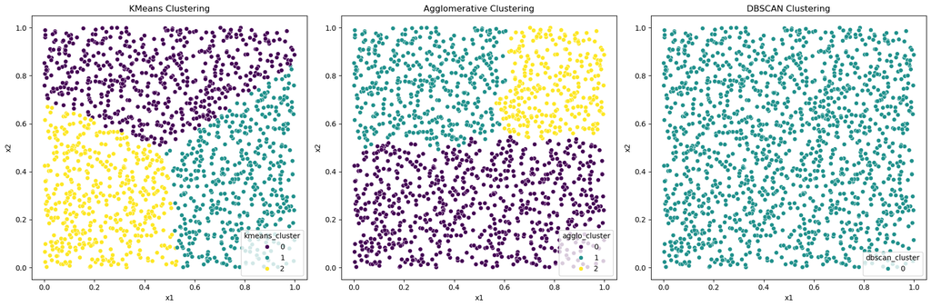

```python
# Create figure and axes for subplots
fig, axes = plt.subplots(1, 3, figsize=(18, 6))

# KMeans Clustering
kmeans = KMeans(n_clusters=3)
kmeans.fit(random_data)
random['kmeans_cluster'] = kmeans.labels_
sns.scatterplot(data=random, x='x1', y='x2', hue='kmeans_cluster', palette='viridis', ax=axes[0])
axes[0].set_title('KMeans Clustering')

# Agglomerative Clustering
agglo = AgglomerativeClustering(n_clusters=3, metric='euclidean')
random['agglo_cluster'] = agglo.fit_predict(random_data)
sns.scatterplot(data=random, x='x1', y='x2', hue='agglo_cluster', palette='viridis', ax=axes[1])
axes[1].set_title('Agglomerative Clustering')

# DBSCAN Clustering
dbscan = DBSCAN(eps=0.1, min_samples=5)
random['dbscan_cluster'] = dbscan.fit_predict(random_data)
sns.scatterplot(data=random, x='x1', y='x2', hue='dbscan_cluster', palette='viridis', ax=axes[2])
axes[2].set_title('DBSCAN Clustering')

# Adjust the layout
plt.tight_layout()
plt.show()
```

# [Interactive plot](https://test-app-y0lp.onrender.com/ml/charts-KMclustDB4/)